# Aside

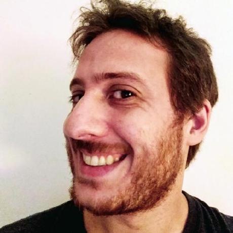

Access this CV online at: danielvartan.github.io/cv-research

## Contact

São Paulo, SP, Brazil

[+55 11 95057-9817](https://wa.me/+5511950579817)

hi@danielvartan.com

danielvartan

danielvartan

0000-0001-7782-759X

## References

### [Prof. Dr. Aline Carvalho](https://orcid.org/0000-0002-4900-5609)

Department of Nutrition  
School of Public Health  
University of São Paulo

### [Prof. Dr. Leandro Garcia](https://orcid.org/0000-0001-5947-2617)

Senior Lecturer in Complexity Science in Public Health  
Centre for Public Health  
Queen’s University Belfast

### [Prof. Dr. Camilo R. Neto](https://orcid.org/0000-0001-6783-6695)

Graduate Program in Complex Systems Modeling  
School of Arts, Sciences and Humanities  
University of São Paulo

## Disclaimer

Developed with [R](https://www.r-project.org)  
pagedown and datadrivencv packages.

Source code available at:  
github.com/danielvartan/cv-research

Last updated on February 17, 2026.

# Main

## Daniel Vartanian

I’m a researcher at the University of São Paulo working on [complex systems](https://en.wikipedia.org/wiki/Complex_system) modeling and data science. My research focuses on [agent-based models](https://en.wikipedia.org/wiki/Agent-based_model), geospatial analysis, and computational approaches to social and public health challenges.

I develop open-source research software, primarily in [R](https://www.r-project.org), [Python](https://www.python.org), and [NetLogo](https://www.netlogo.org). My tools are used by researchers studying chronobiology, food security, and climate impacts on health systems.

Outside work, I’m involved in building scientific communities and contributing to open-source projects through [rOpenSci](https://ropensci.org) and the [NetLogo](https://www.netlogo.org) ecosystem.

## Research Experience

### Research Fellow

[Center for Metropolitan Studies](https://centrodametropole.fflch.usp.br) ([FFLCH](https://www.fflch.usp.br)-[USP](https://www.usp.br))

São Paulo, SP, Brazil

Present - 2025

- Lead geospatial modeling and large-scale data mining on the [FAPESP](https://fapesp.br)-funded [AcessoSAN](https://osf.io/ze6wt) project, investigating healthy food access in favelas and low-income urban communities across Brazil.
- Built reproducible [R](https://www.r-project.org/) and [Quarto](https://quarto.org/) pipelines to process and analyze millions of records from [SISVAN](https://sisaps.saude.gov.br/sisvan), [Brazilian Revenue Service](https://www.gov.br/receitafederal), [DATASUS](https://datasus.saude.gov.br), [IBGE Census](https://www.ibge.gov.br/), and climate datasets like [WorldClim 2.1](https://www.worldclim.org) and [Mapbiomas](https://brasil.mapbiomas.org).
- Collaborate with interdisciplinary teams of nutritionists, sociologists, health professionals, and engineers across multiple [USP](https://www.usp.br) departments.

### Research Fellow

[Sustentarea](https://www.fsp.usp.br/sustentarea) ([FSP](https://www.fsp.usp.br)-[USP](https://www.usp.br))

São Paulo, SP, Brazil

2025 - 2024

- Led agent-based modeling on the [CNPq](https://www.gov.br/cnpq)-funded [Global Syndemic](https://doi.org/10.17605/OSF.IO/8W36C) project investigating climate change effects on child nutrition and health in Brazil.
- Developed [NetLogo](https://www.netlogo.org) models simulating food production systems and nutritional outcomes in children under 5, using climate projections from [Global Climate Models](https://www.worldclim.org/) and [IBGE](https://sidra.ibge.gov.br) data.
- Created the [logolink](https://danielvartan.github.io/logolink/) R package to provide analytical infrastructure for [NetLogo](https://www.netlogo.org) simulations.
- Produced research papers (submitted), reproducible analysis pipelines, and technical reports for cross-institutional teams of health researchers and climate scientists from [USP](https://www.usp.br) and the RESICLIMA Network.

### Graduate Research Fellow

University of São Paulo ([USP](https://www.usp.br))

São Paulo, SP, Brazil

2025 - 2022

- Developed nested linear models investigating the relationship between human chronotype and latitude using Brazil’s largest chronotype dataset (n=115,166).
- Created the mctq R package (published on [CRAN](https://cran.r-project.org), peer-reviewed by [rOpenSci](https://ropensci.org)) for processing chronotype questionnaires.
- Built reproducible analysis pipelines in [R](https://www.r-project.org/) and [Quarto](https://quarto.org/) for statistical modeling and data processing.
- Completed [master’s thesis](https://danielvartan.github.io/mastersthesis) on chronotype and latitude relationships.

### Assistant Research Fellow

University of São Paulo ([USP](https://www.usp.br))

São Paulo, SP, Brazil

2022 - 2019

- Developed [actigraphy](https://en.wikipedia.org/wiki/Actigraphy) monitoring protocols and analytical models for circadian rhythm assessment using non-parametric methods, cosinor analysis, periodograms, and actogram visualizations.
- Created the actverse R package providing tools for [actigraphy](https://en.wikipedia.org/wiki/Actigraphy) data analysis.
- Co-authored the first [Brazilian Actigraphy Consensus](https://www.researchgate.net/publication/358348693_Consenso_Brasileiro_de_Actigrafia) and delivered training workshops to 60+ researchers, including a launch workshop at the 18th Brazilian Sleep Congress.
- Contributed to [USP](https://www.usp.br)’s Sleep Genetics project investigating associations between [chronotype](https://en.wikipedia.org/wiki/Chronotype) and [clock genes](https://en.wikipedia.org/wiki/Circadian_clock) using [actigraphy](https://en.wikipedia.org/wiki/Actigraphy) and genetic data from saliva samples across multi-centric cohorts in São Paulo and Baependi, Minas Gerais.

### Undergraduate Research Fellow

University of São Paulo ([USP](https://www.usp.br))

São Paulo, SP, Brazil

2019 - 2016

- Provided statistical modeling and data analysis support for [circadian rhythm](https://en.wikipedia.org/wiki/Circadian_rhythm) and sleep research projects.
- Served as head of marketing and communications for [USP](https://www.usp.br)’s Interdisciplinary Sleep Research Group ([GIPSO](https://dgp.cnpq.br/dgp/espelhogrupo/0840395566366418)), securing media coverage in major Brazilian outlets like *Folha de São Paulo* and [TV Globo’s *Fantástico*](https://g1.globo.com/fantastico/noticia/2017/10/metade-da-populacao-se-sente-mal-no-horario-de-verao-revela-pesquisa.html).
- Co-developed sleep science courses through [EACH](https://each.usp.br)-[USP](https://www.usp.br)’s summer program and the [Coursera](https://www.coursera.org/learn/biologiadosono) platform.

## Programming Languages

danielvartan

### Expert

`R`

`NetLogo`

### Fluent

`Python`

`SQL`

### Intermediate

`Bash`

`C` `C++` `C#`

`GAML` ([GAMA](https://gama-platform.org/))

`JavaScript`

`Lua`

### Basic Proficiency

`GDScript` ([Godot](https://godotengine.org))

`Julia`

`Rust`

### Markup/Other Languages

`CSS`

`Git`

`HTML`

`Markdown`

`SASS`

`TeX` `LaTeX`

## Education

### MSc, Complex Systems Modeling

University of São Paulo ([USP](https://www.usp.br))

São Paulo, SP, Brazil

2025 - 2022

- Focus on agent-based and computational modeling of complex social and environmental systems.
- Founded USP’s [Agent-Based Modeling Study Group](https://abmstudygroup.org).
- Thesis: [danielvartan.github.io/mastersthesis](https://danielvartan.github.io/mastersthesis/)

### BSc, Marketing

University of São Paulo ([USP](https://www.usp.br))

São Paulo, SP, Brazil

2022 - 2016

- Final grade: 7.7/10 (23rd/66)
- Strong quantitative foundation in calculus, statistics, and finance.
- Co-founded [EACH](https://www.each.usp.br)-[USP](https://www.usp.br)’s [Wellness and Health Commission](http://www5.each.usp.br/wp-content/uploads/2015/11/Port-045_18-Comiss%C3%A3o-de-Saude-Bem-Estar.pdf).

## Teaching Experience

### [An Introduction to the R Programming Language](https://danielvartan.github.io/r-course)

University of São Paulo ([USP](https://www.usp.br))

São Paulo, SP, Brazil

2026 - 2025

- Developed and delivered introductory R programming course for researchers at the School of Public Health ([FSP](https://www.fsp.usp.br)) (2025) and School of Philosophy, Literature and Human Sciences ([FFLCH](https://www.fflch.usp.br)) (2026) at the University of São Paulo ([USP](https://www.usp.br)).
- Trained approximately 30 researchers across both institutions.

### [Technical High School Program in Administration](https://www.imprensaoficial.com.br/Certificacao/GatewayCertificaPDF.aspx?notarizacaoID=e3a88ea6-68b4-4957-94af-46b9368300c7)

[São Paulo State Government](https://www.educacao.sp.gov.br/)

São Paulo, SP, Brazil

2024

- Taught mathematics to approximately 100 students across two public high schools in São Paulo State’s technical education program.

### [ACH0042 - Problem Based Learning II](https://uspdigital.usp.br/jupiterweb/obterDisciplina?nomdis=&sgldis=ACH0042)

University of São Paulo ([USP](https://www.usp.br))

São Paulo, SP, Brazil

2023

- Taught science and computational methods to 60 information systems students at [EACH](https://each.usp.br)-[USP](https://www.usp.br).

### [Introductory Course on Actigraphy](https://web.archive.org/web/20211026202625/https://www.sono2021.com.br/evento/sono2021/programacao/gradeatividades)

18th Brazilian Sleep Congress

São Paulo, SP, Brazil

2021

- Co-delivered actigraphy training workshop accompanying the launch of the Brazilian Actigraphy Consensus.
- Trained approximately 40 sleep researchers and health professionals.

## Affiliations

### [Center for Metropolitan Studies](https://centrodametropole.fflch.usp.br)

Researcher (2025-Present)

### [RESICLIMA Network](https://resiclima.com.br/quem-somos/)

Researcher (2024-Present)

### [Sustentarea](https://www.fsp.usp.br/sustentarea/)

Researcher (2024-Present)

### [rOpenSci](https://ropensci.org)

Software Developer (2021-Present)

### Interdisciplinary Sleep Research Group ([GIPSO](https://dgp.cnpq.br/dgp/espelhogrupo/0840395566366418))

Researcher (2016-2022)

## Languages

danielvartan

### English

Fluent

Fluent

Fluent

Fluent

### Portuguese

Native

Native

Native

Native

### Spanish

Proficient

Proficient

Intermediate

Intermediate

### French

Beginner

Beginner

Beginner

Beginner

## Selected Publications

### [Is Latitude Associated with Chronotype?](https://danielvartan.github.io/mastersthesis/)

University of São Paulo ([USP](https://www5.usp.br/))

N/A

2025

Vartanian, D. (2025). *Is latitude associated with chronotype?* [Master’s thesis, University of São Paulo]. https://doi.org/10.11606/D.100.2025.tde-02042025-063648

### [Actigraphic Characterization of Sleep and Circadian Phenotypes of PER3 Gene VNTR Genotypes](https://doi.org/10.1080/07420528.2023.2256858)

Chronobiology International

N/A

2023

Viana-Mendes, J., Benedito-Silva, A. A., Andrade, M. A. M., Vartanian, D., Gonçalves, B. da S. B., Cipolla-Neto, J., & Pedrazzoli, M. (2023). Actigraphic characterization of sleep and circadian phenotypes of PER3 gene VNTR genotypes. *Chronobiology International*, *40*(9), 1244–1250. https://doi.org/10.1080/07420528.2023.2256858

### [Brazilian Actigraphy Consensus](https://www.researchgate.net/publication/358348693_Consenso_Brasileiro_de_Actigrafia)

Segmento Farma Editores

N/A

2021

Pedrazzoli, M., & Gonçalves, B. S. B. (Eds.) (with Benedito-Silva, A. A., Toscanini, A. C., Souza, A. P. P. B., Conway, B. A., Vartanian, D., Santos, E. H. R., Pires, M. L. N., & Leocadio-Miguel, M. A.). (2021). *Consenso brasileiro de actigrafia* [Brazilian actigraphy consensus]. Segmento Farma Editores. ISBN 978-65-992059-6-5.

### [Early Chronotype with Advanced Activity Rhythms and Dim Light Melatonin Onset in a Rural Population](https://doi.org/10.1111/jpi.12675)

Journal of Pineal Research

N/A

2020

Ruiz, F. S., Beijamini, F., Beale, A. D., Gonçalves, B. D. S. B., Vartanian, D., Taporoski, T. P., Middleton, B., Krieger, J. E., Vallada, H., Arendt, J., Pereira, A. C., Knutson, K. L., Pedrazzoli, M., & Von Schantz, M. (2020). Early chronotype with advanced activity rhythms and dim light melatonin onset in a rural population. *Journal of Pineal Research*, *69*(3). https://doi.org/10.1111/jpi.12675

## Selected Software Projects

### [LogoActions](https://github.com/danielvartan/logoactions)

Creator and Maintainer

GitHub

2026

[GitHub Actions](https://github.com/features/actions) for the [NetLogo](https://www.netlogo.org) community.

### logolink

Creator and Maintainer

CRAN

2025

[R](https://www.r-project.org) package providing a [tidy](https://tidyverse.tidyverse.org/articles/manifesto.html) interface between [R](https://www.r-project.org) and [NetLogo](https://www.netlogo.org).

- Published on [CRAN](https://doi.org/10.32614/CRAN.package.logolink) (1,200+ downloads).
- Currently under [peer review](https://github.com/ropensci/software-review/issues/741) by [rOpenSci](https://ropensci.org).

### [LogoClim](https://github.com/sustentarea/logoclim)

Creator and Maintainer

CoMSES Net

2025

[NetLogo](https://www.netlogo.org) model developed to simulate and visualize climate conditions using data from [WorldClim 2.1](https://worldclim.org).

- Published on [CoMSES Net](https://www.comses.net/codebases/bccd451f-76a4-408a-85fd-c5024359ba9a).
- Currently under [peer review](https://joss.theoj.org/papers/093e7333c6a34b5f3dc0b44b76e05480) in [JOSS](https://joss.theoj.org) (2025).

### actverse

Creator and Maintainer

GitHub

2023

[R](https://www.r-project.org) package providing a [tidy](https://tidyverse.tidyverse.org/articles/manifesto.html) toolbox for [actigraphy](https://en.wikipedia.org/wiki/Actigraphy) data analysis.

### mctq

Creator and Maintainer

CRAN

2021

[R](https://www.r-project.org) package providing a [tidy](https://tidyverse.tidyverse.org/articles/manifesto.html) toolbox for processing the Munich ChronoType Questionnaire ([MCTQ](https://doi.org/10.1177/0748730402239679)).

- Published on [CRAN](https://doi.org/10.32614/CRAN.package.mctq) (13,000+ downloads).
- [Peer reviewed](https://github.com/ropensci/software-review/issues/434) by [rOpenSci](https://ropensci.org).
- Cited in chronobiology research across multiple countries.

## Selected Outreach Projects

### Interdisciplinary Brazilian Symposium on Agent-Based Models ([SIMBRA](https://simbra.com.br))

University of São Paulo ([USP](https://www.usp.br))

São Paulo, SP, Brazil

Present - 2025

Co-founded SIMBRA as an extension of USP’s [Agent-Based Modeling Study Group](https://abmstudygroup.org) to provide a national platform for researchers and students across disciplines to discuss and disseminate agent-based modeling approaches.

### [Durma na EACH](https://photos.app.goo.gl/spUsAgPNhdnEXQja8) (*Sleep at EACH*)

University of São Paulo ([USP](https://www.usp.br))

São Paulo, SP, Brazil

2018 - 2017

Created sleep and rest spaces for students at [EACH](https://each.usp.br)-[USP](https://www.usp.br) with plans for expansion to São Paulo public schools.